# Lesson 6 - 04/21/2015

### Chris Saden’s analysis of the same diamond data set

https://s3.amazonaws.com/udacity-hosted-downloads/ud651/diamondsExample.html

### Scatterplot Review

Notes: Real dataset from 2008

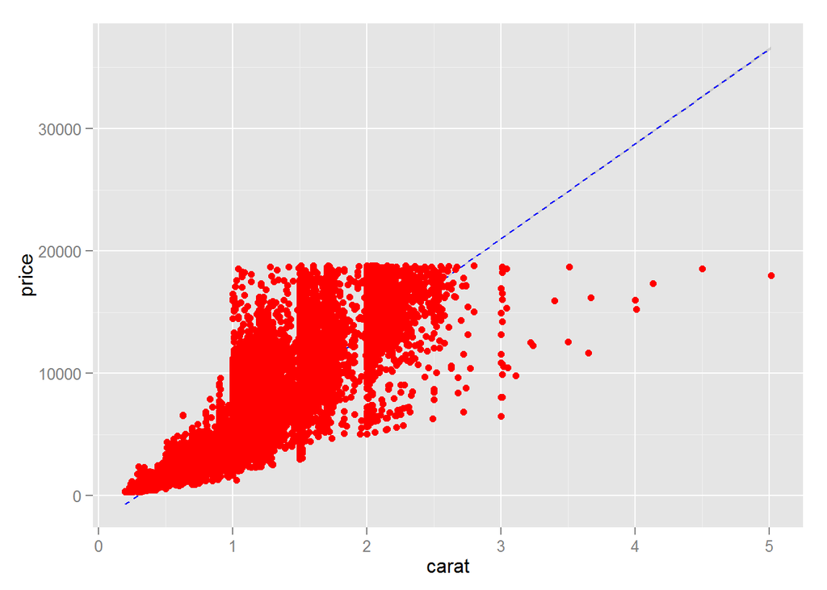

```r
library('ggplot2')
data(diamonds)
ggplot(data = diamonds, aes(x = carat, y = price),
       xlim = c(0, quantile(carat, probs = 0.99)),
       ylim = c(0, quantile(price, probs = 0.99))) +
  geom_smooth(method = 'lm', color = 'blue', linetype = 2) +
  geom_point(color = 'red')
```

Response: - Price = fexp(carat) - But we also see variance increase as the carat size increases

### ggpairs Function

Notes: Scatter Plot matrix - quant-quant –> displays r and scatterplots - qual-quant –> displays histogram and boxplots - qual- qual –> displays histogram and boxplots again

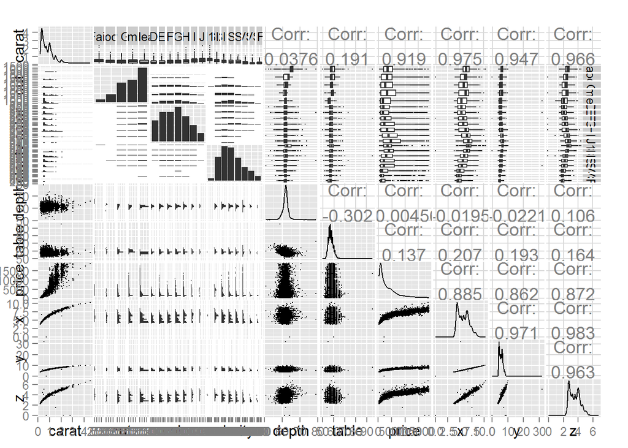

```r
# install these if necessary
# install.packages('GGally')
# install.packages('scales')
# install.packages('memisc')
# install.packages('lattice')
# install.packages('MASS')
# install.packages('car')
# install.packages('reshape')
# install.packages('plyr')

# load the ggplot graphics package and the others
library(ggplot2)
library(GGally)
library(scales)
library(memisc)
# sample 10,000 diamonds from the data set
set.seed(20022012)
# Easier to follow syntax - some error, debug later
# sample_price <- sample(x = diamonds$price, size = 10000)
# diamond_samp <- subset(diamonds, sample_price %in% price)
# head(diamond_samp)
diamond_samp <- diamonds[sample(1:length(diamonds$price), 10000), ]
ggpairs(diamond_samp, params = c(shape = I('.'), outlier.shape = I('.')))
```

```r
ggsave("D:/EDA/R_wd/Project/sp_matrix.pdf")
```

What are some things you notice in the ggpairs output? Response: - x, y and z are almost perfectly correlated to each other (means diamonds always come in same shapes) - price is also quite strongly correlated to x, y, z (ie volume of diamond) - carat is strongly correlated to price and x, y, z (which we expected) - depth shows no impact on price (reject feature for price prediction) - We already saw the weird inverse relation of color and clarity to price (against intuition) - Nothing substantial stands out wrt. to cut, but we cannot eliminate it just yet - Hypothesize that since weight is a function of volume, price may be related to cube of carat

### The Demand of Diamonds

Notes: - Maybe the case that in the smaller diamonds, there is less affluent buyers, so this is price sensitive. This makes the variation of price for sub-carat diamonds not show much variation - For larger sizes, there is not much demand, and demand is from affluent people. So, possibly much wider variation in prices for weight > 1 carat

- May be instrumental to transform the price variable using log http://www.r-statistics.com/2013/05/log-transformations-for-skewed-and-wide-distributions-from-practical-data-science-with-r/

```r
library(gridExtra)
```

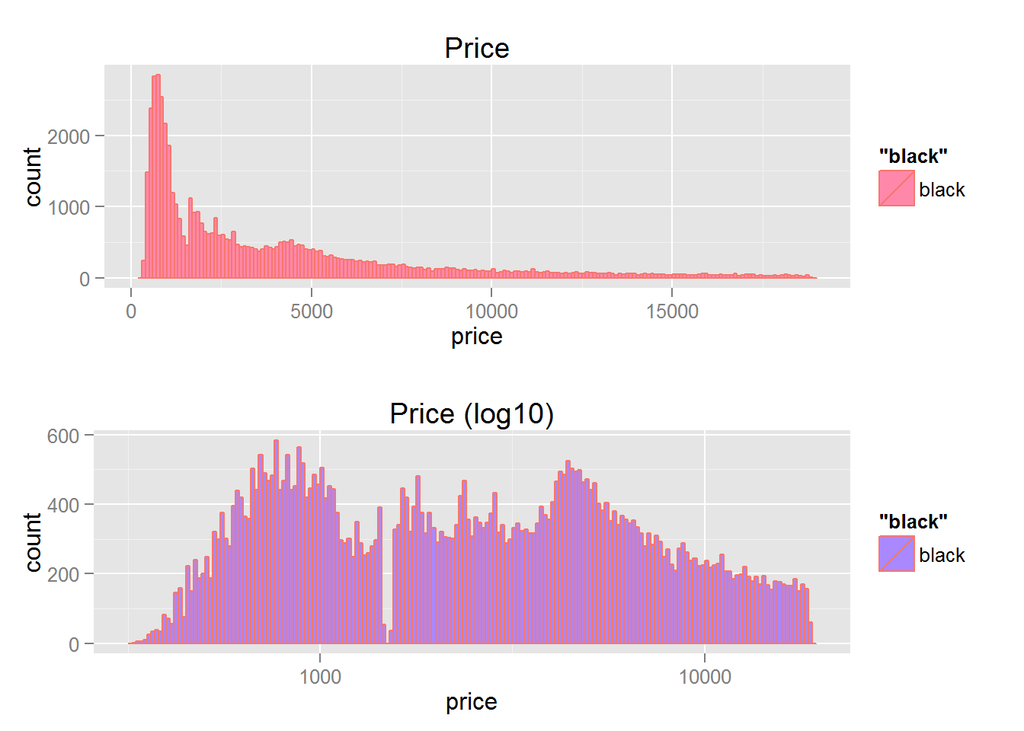

```r
plot1 <- qplot(data = subset(diamonds, price > 0) , x= price, color = 'black', fill = I('#ff88aa'), binwidth = 100) +
  ggtitle('Price')

# Note, in log plot, you have to pick bin width after the transformation
plot2 <- qplot(data = subset(diamonds, price > 0), x = price, color = 'black', fill = I('#aa88ff'), binwidth = 0.01) +
  scale_x_log10() +
  ggtitle('Price (log10)')

grid.arrange(plot1, plot2, ncol = 1)
```

Notes: - - Price distribution is +vely skewed with long tail. Hence, log10 transformation should help convert to near normal - Note that for applying LR, we only require inputs to be approx normal, not the the output itself - Money is also multiplicative - year on year inflation, path dependent (rich become richer) etc - For monetary variables, which are highly skewed and have orders of magnitude variance, it is useful to apply log transformation - This also helps data models which don’t do well when there is orders of magnitude difference Post, transformation, we see it is bimodal, but closer to normal, so we will apply LR on log10(y) instead of y

### Connecting Demand and Price Distributions

Notes: - First peak for price senstive customers - Second peak is for affluent customers. Beyond a point, they also don’t think its worth it apparently

### Scatterplot Transformation

Notes: Transform price using log10 due to it being reasons above

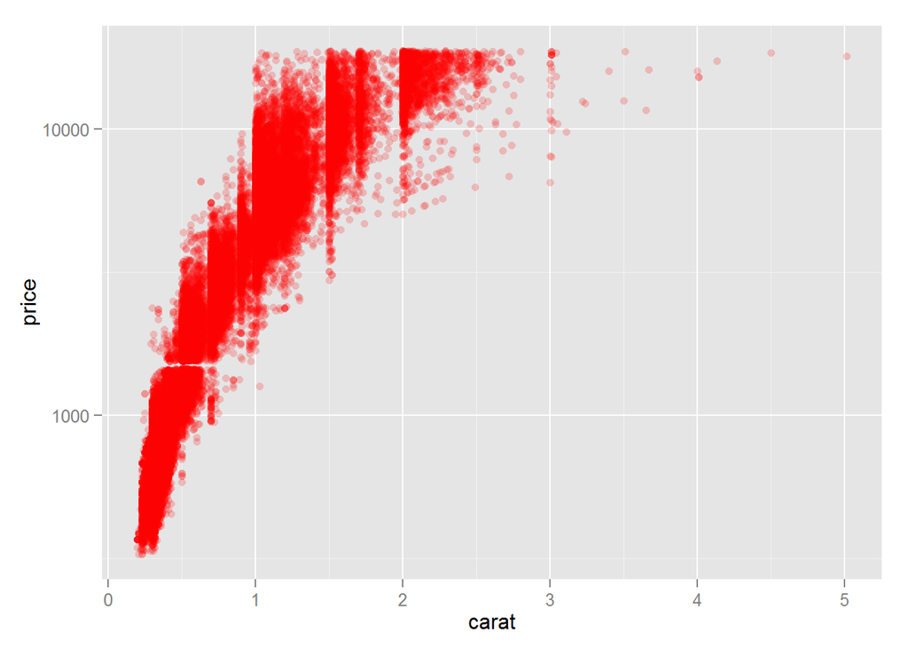

```r
ggplot(data = diamonds, aes(x = carat, y = price),
       xlim = c(0, quantile(carat, probs = 0.99)),
       ylim = c(0, quantile(price, probs = 0.99))) +
  geom_point(color = 'red', alpha = 1/5) +
  scale_y_log10()
```

### Some useful functions

```r
input <- seq(0, 10, 0.1)
ylin <- input
ysq <- input^2
ycube <- input^3
func.df <- data.frame(input, ylin, ysq, ycube)
str(func.df)
```

```
## 'data.frame':    101 obs. of  4 variables:
##  $ input: num  0 0.1 0.2 0.3 0.4 0.5 0.6 0.7 0.8 0.9 ...
##  $ ylin : num  0 0.1 0.2 0.3 0.4 0.5 0.6 0.7 0.8 0.9 ...
##  $ ysq  : num  0 0.01 0.04 0.09 0.16 0.25 0.36 0.49 0.64 0.81 ...
##  $ ycube: num  0 0.001 0.008 0.027 0.064 0.125 0.216 0.343 0.512 0.729 ...
```

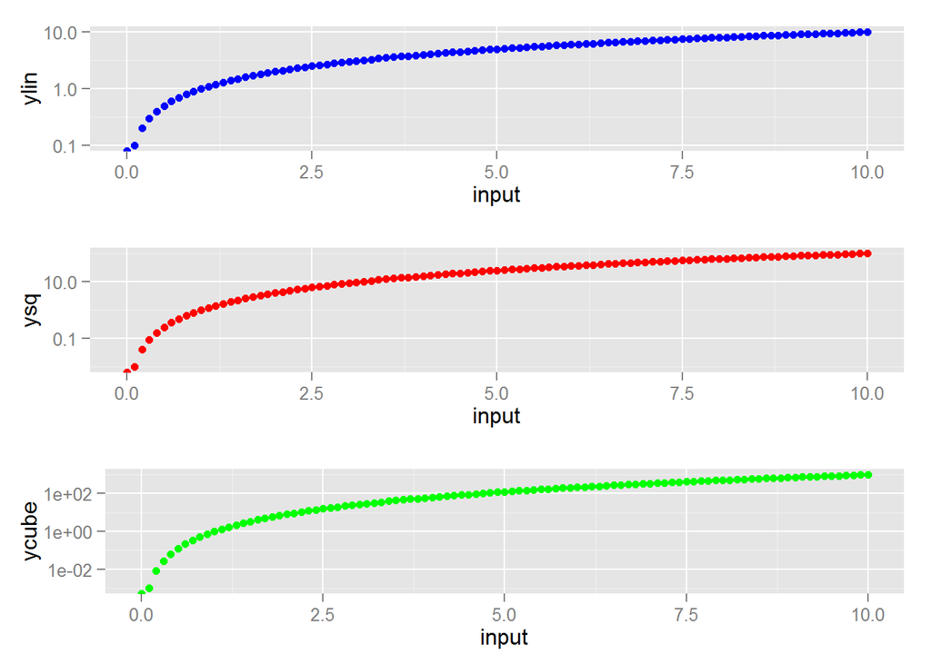

```r
p1 <- ggplot(data = func.df, aes(x = input, y = ylin)) +
  geom_point(color = 'blue', linetype = 2) +
  scale_y_log10()
p2 <- ggplot(data = func.df, aes(x = input, y = ysq)) +
  geom_point(color = 'red', linetype = 3) +
  scale_y_log10()
p3 <- ggplot(data = func.df, aes(x = input, y = ycube)) +
  geom_point(color = 'green') +
  scale_y_log10()
grid.arrange(p1, p2, p3, ncol = 1)
```

```r
ylin <- input
ysqr <- input^(1/2)
ycuber <- input^(1/3)
func.df <- data.frame(input, ylin, ysq, ycube)
str(func.df)
```

```
## 'data.frame':    101 obs. of  4 variables:
##  $ input: num  0 0.1 0.2 0.3 0.4 0.5 0.6 0.7 0.8 0.9 ...
##  $ ylin : num  0 0.1 0.2 0.3 0.4 0.5 0.6 0.7 0.8 0.9 ...
##  $ ysq  : num  0 0.01 0.04 0.09 0.16 0.25 0.36 0.49 0.64 0.81 ...
##  $ ycube: num  0 0.001 0.008 0.027 0.064 0.125 0.216 0.343 0.512 0.729 ...
```

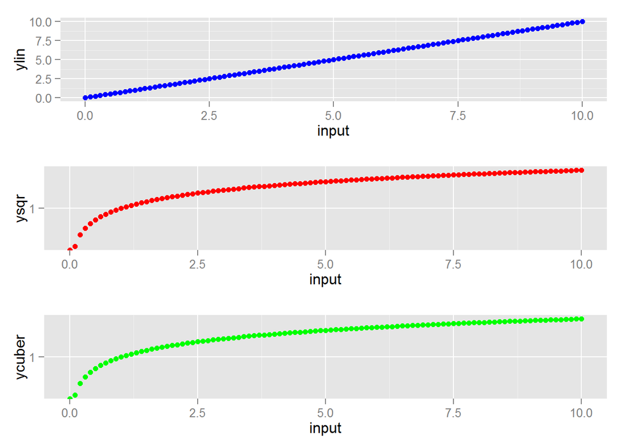

```r
p4 <- ggplot(data = func.df, aes(x = input, y = ylin)) +
  geom_point(color = 'blue', linetype = 2)
p5 <- ggplot(data = func.df, aes(x = input, y = ysqr)) +
  geom_point(color = 'red', linetype = 3) +
  scale_y_log10()
p6 <- ggplot(data = func.df, aes(x = input, y = ycuber)) +
  geom_point(color = 'green') +
  scale_y_log10()
grid.arrange(p4, p5, p6, ncol = 1)
```

### Create a new function to transform the carat variable

Notes: https://www.youtube.com/watch?v=Z1wB1rHAYzQ&list=PLOU2XLYxmsIK9qQfztXeybpHvru-TrqAP http://blog.ggplot2.org/post/25938265813/defining-a-new-transformation-for-ggplot2-scales

Note: Write a general function called ‘cuberoot_trans()’ that returns the cube root of input param

```r
cuberoot_trans = function() trans_new('cuberoot', transform = function(x) x^(1/3),
                                      inverse = function(x) x^(3))
```

#### Use the cuberoot_trans function

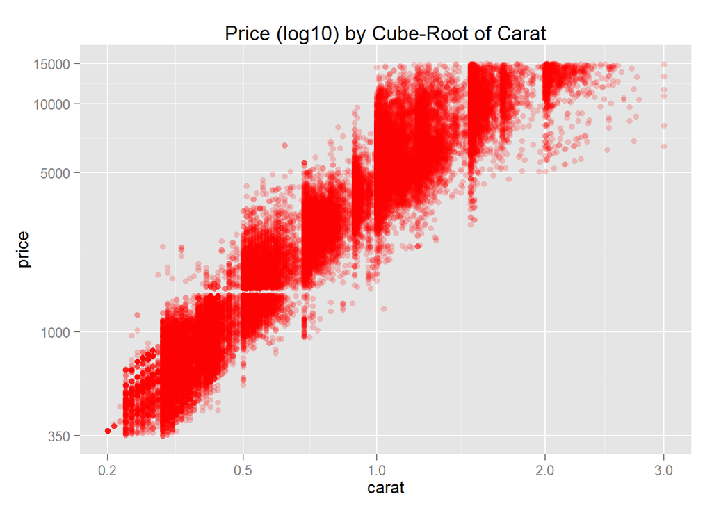

```r
ggplot(aes(carat, price), data = diamonds) +
  geom_point(color = 'red', alpha = 1/5) +
#  scale_x_continuous(trans = cuberoot_trans()) +
  scale_x_continuous(trans = cuberoot_trans(), limits = c(0.2, 3),
                     breaks = c(0.2, 0.5, 1, 2, 3)) +
  scale_y_continuous(trans = log10_trans(), limits = c(350, 15000),
                     breaks = c(350, 1000, 5000, 10000, 15000)) +
  ggtitle('Price (log10) by Cube-Root of Carat')
```

Response: - Viola, it looks linear now - Note, the cube root hint also comes from the strong correlation of each dimension to price

### Overplotting Revisited

```r
head(sort(table(diamonds$price), decreasing = T))     # sorts by frequency
```

```
##
## 605 802 625 828 776 698
## 132 127 126 125 124 121
```

```r
head(sort(table(diamonds$carat), decreasing = T))
```

```
##
##  0.3 0.31 1.01  0.7 0.32    1
## 2604 2249 2242 1981 1840 1558
```

Response: Shows you can really end up overplotting with the number of points at the same carat/price level

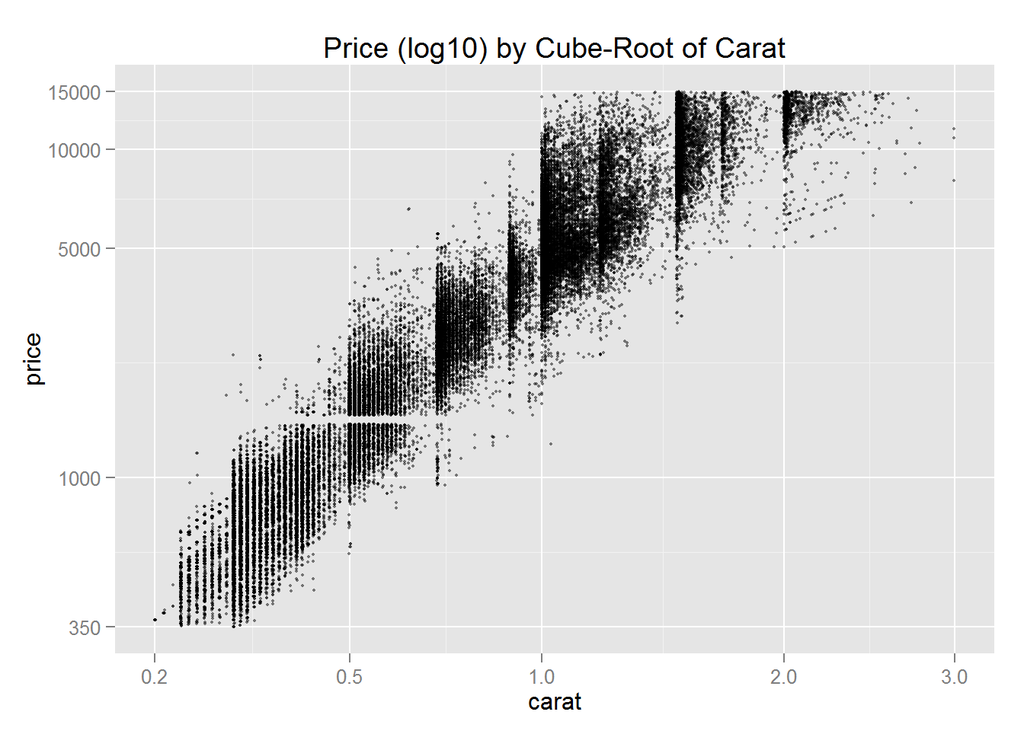

```r
ggplot(aes(carat, price), data = diamonds) +
  geom_jitter(alpha = 0.5, size = 0.75) +
  scale_x_continuous(trans = cuberoot_trans(), limits = c(0.2, 3),
                     breaks = c(0.2, 0.5, 1, 2, 3)) +
  scale_y_continuous(trans = log10_trans(), limits = c(350, 15000),
                     breaks = c(350, 1000, 5000, 10000, 15000)) +
  ggtitle('Price (log10) by Cube-Root of Carat')
```

### Other Qualitative Factors

Notes:

### Price vs. Carat and Clarity

Notes: http://www.bluenile.com/education/diamonds/cut http://www.bluenile.com/education/diamonds/color http://www.bluenile.com/education/diamonds/clarity

http://docs.ggplot2.org/current/scale_brewer.html http://www.cookbook-r.com/Graphs/Colors_(ggplot2)/#palettes-color-brewer http://www.cookbook-r.com/Graphs/Legends_(ggplot2)/

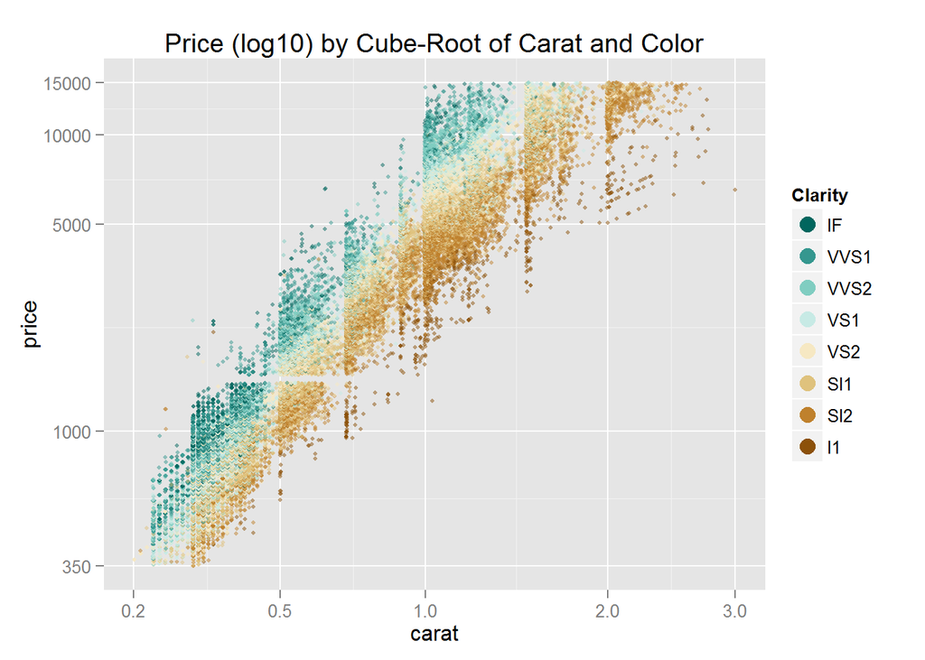

```r
# install and load the RColorBrewer package
# install.packages('RColorBrewer')
# library(RColorBrewer)

# legend just tells you what to do while printing legend (overrides alpha and size so it is visible better)
# Reverse is because we want clarity displayed in descending order
ggplot(aes(x = carat, y = price), data = diamonds) +
  geom_point(alpha = 0.5, size = 1, position = 'jitter', aes(color = clarity)) +
  scale_color_brewer(type = 'div',
    guide = guide_legend(title = 'Clarity', reverse = T,
    override.aes = list(alpha = 1, size = 4))) +
  scale_x_continuous(trans = cuberoot_trans(), limits = c(0.2, 3),
    breaks = c(0.2, 0.5, 1, 2, 3)) +
  scale_y_continuous(trans = log10_trans(), limits = c(350, 15000),
    breaks = c(350, 1000, 5000, 10000, 15000)) +
  ggtitle('Price (log10) by Cube-Root of Carat and Color')
```

### Clarity and Price

Response: Based on the plot, we can see that when the clarity increases, we see the price leaning towards the higher end of the band.

### Price vs. Carat and Cut

Alter the code below.

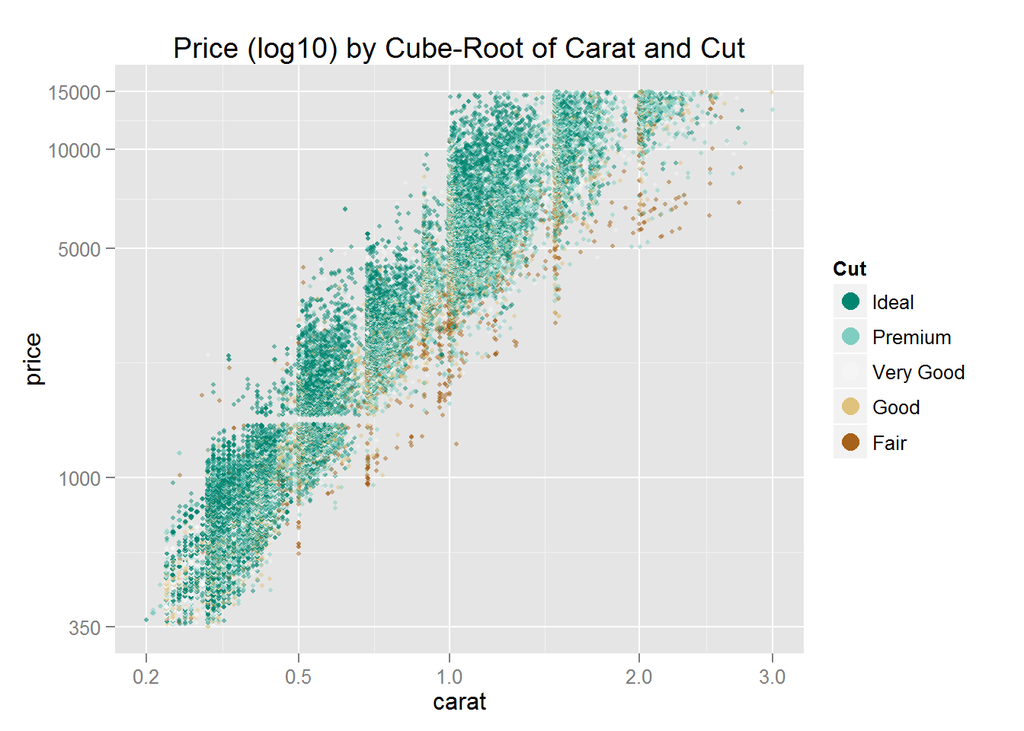

```r
ggplot(aes(x = carat, y = price, color = cut), data = diamonds) +
  geom_point(alpha = 0.5, size = 1, position = 'jitter') +
  scale_color_brewer(type = 'div',
                     guide = guide_legend(title = 'Cut', reverse = T,
                                          override.aes = list(alpha = 1, size = 4))) +
  scale_x_continuous(trans = cuberoot_trans(), limits = c(0.2, 3),
                     breaks = c(0.2, 0.5, 1, 2, 3)) +
  scale_y_continuous(trans = log10_trans(), limits = c(350, 15000),
                     breaks = c(350, 1000, 5000, 10000, 15000)) +
  ggtitle('Price (log10) by Cube-Root of Carat and Cut')
```

### Cut and Price

Response: Based on plot, cuts are dispersed along Y axis, so no clear relation to cut and price

### Price vs. Carat and Color

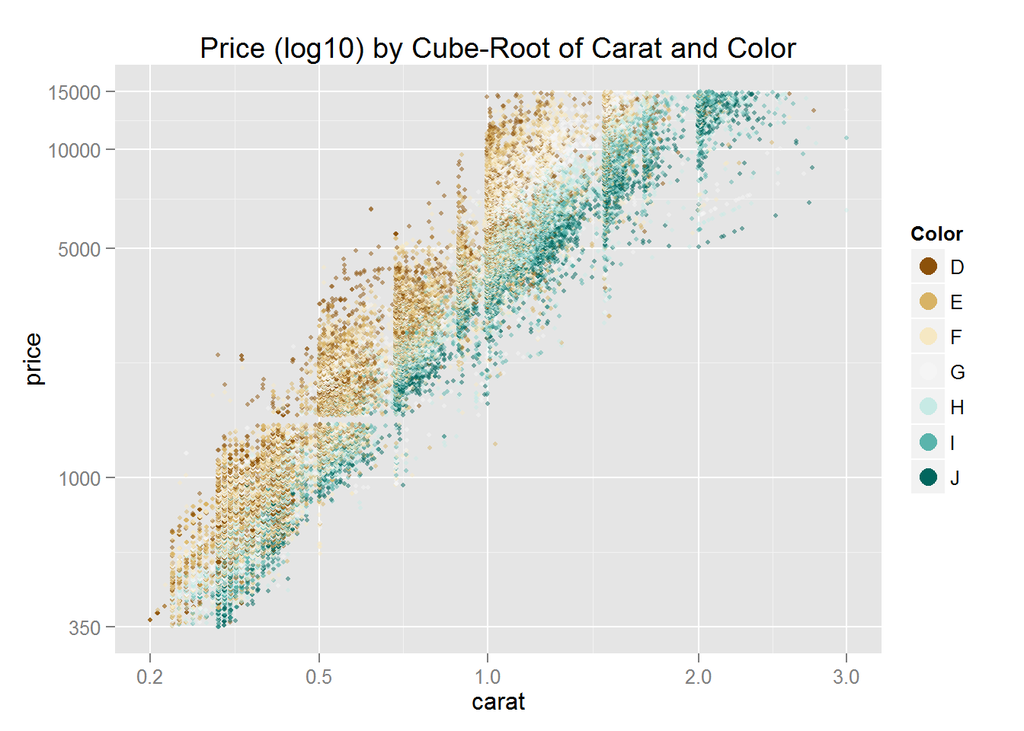

```r
ggplot(aes(x = carat, y = price, color = color), data = diamonds) +
  geom_point(alpha = 0.5, size = 1, position = 'jitter') +
  scale_color_brewer(type = 'div',
                     guide = guide_legend(title = 'Color', reverse = F,
                                          override.aes = list(alpha = 1, size = 4))) +
  scale_x_continuous(trans = cuberoot_trans(), limits = c(0.2, 3),
                     breaks = c(0.2, 0.5, 1, 2, 3)) +
  scale_y_continuous(trans = log10_trans(), limits = c(350, 15000),
                     breaks = c(350, 1000, 5000, 10000, 15000)) +
  ggtitle('Price (log10) by Cube-Root of Carat and Color')
```

### Color and Price

Response: Based on this, we see that color plays a role similar to clarity, but the boundaries are less distinct. This is most likely because D to J are all still excellent colors with color barely detectable except in I-J

### Linear Models in R

Notes: use lm(output ~ input_func) to perform linear regression

Response: - Use lm(log(price) ~ carat^(1/3)) based on our plot

### Building the Linear Model

Notes: http://data.princeton.edu/R/linearModels.html Interpreting Regression Coefficients in R - http://www.r-bloggers.com/interpreting-regression-coefficient-in-r/?utm_source=feedburner&utm_medium=email&utm_campaign=Feed%3A+RBloggers+%28R+bloggers%29 Interpreting Regression Coefficients on the Analysis Factor blog http://www.theanalysisfactor.com/interpreting-regression-coefficients/ Fitting and Interpreting Linear Models by yhat http://blog.yhathq.com/posts/r-lm-summary.html Another Explanation of Factor Coefficients in Linear Models on Stats StackExchange http://stats.stackexchange.com/a/24256

```r
m1 <- lm(I(log(price)) ~ I(carat^(1/3)), data = diamonds)
m2 <- update(m1, ~ . + carat)
m3 <- update(m2, ~ . + cut)
m4 <- update(m3, ~ . + color)
m5 <- update(m4, ~ . + clarity)
mtable(m1, m2, m3, m4, m5)
```

```
##
## Calls:
## m1: lm(formula = I(log(price)) ~ I(carat^(1/3)), data = diamonds)
## m2: lm(formula = I(log(price)) ~ I(carat^(1/3)) + carat, data = diamonds)
## m3: lm(formula = I(log(price)) ~ I(carat^(1/3)) + carat + cut, data = diamonds)
## m4: lm(formula = I(log(price)) ~ I(carat^(1/3)) + carat + cut + color,
##     data = diamonds)
## m5: lm(formula = I(log(price)) ~ I(carat^(1/3)) + carat + cut + color +
##     clarity, data = diamonds)
##
## ======================================================================
##                     m1         m2         m3         m4         m5
## ----------------------------------------------------------------------
## (Intercept)      2.821***   1.039***   0.874***   0.932***   0.415***
##                 (0.006)    (0.019)    (0.019)    (0.017)    (0.010)
## I(carat^(1/3))   5.558***   8.568***   8.703***   8.438***   9.144***
##                 (0.007)    (0.032)    (0.031)    (0.028)    (0.016)
## carat                      -1.137***  -1.163***  -0.992***  -1.093***
##                            (0.012)    (0.011)    (0.010)    (0.006)
## cut: .L                                0.224***   0.224***   0.120***
##                                       (0.004)    (0.004)    (0.002)
## cut: .Q                               -0.062***  -0.062***  -0.031***
##                                       (0.004)    (0.003)    (0.002)
## cut: .C                                0.051***   0.052***   0.014***
##                                       (0.003)    (0.003)    (0.002)
## cut: ^4                                0.018***   0.018***  -0.002
##                                       (0.003)    (0.002)    (0.001)
## color: .L                                        -0.373***  -0.441***
##                                                  (0.003)    (0.002)
## color: .Q                                        -0.129***  -0.093***
##                                                  (0.003)    (0.002)
## color: .C                                         0.001     -0.013***
##                                                  (0.003)    (0.002)
## color: ^4                                         0.029***   0.012***
##                                                  (0.003)    (0.002)
## color: ^5                                        -0.016***  -0.003*
##                                                  (0.003)    (0.001)
## color: ^6                                        -0.023***   0.001
##                                                  (0.002)    (0.001)
## clarity: .L                                                  0.907***
```

[output cut: 10 more lines]

```
##                                                             (0.002)
## clarity: ^7                                                  0.032***
##                                                             (0.001)
## ----------------------------------------------------------------------
## R-squared            0.924      0.935      0.939     0.951       0.984
## adj. R-squared       0.924      0.935      0.939     0.951       0.984
## sigma                0.280      0.259      0.250     0.224       0.129
## F               652012.063 387489.366 138654.523 87959.467  173791.084
## p                    0.000      0.000      0.000     0.000       0.000
## Log-likelihood   -7962.499  -3631.319  -1837.416  4235.240   34091.272
## Deviance          4242.831   3613.360   3380.837  2699.212     892.214
## AIC              15930.999   7270.637   3690.832 -8442.481  -68140.544
## BIC              15957.685   7306.220   3761.997 -8317.942  -67953.736
## N                53940      53940      53940     53940       53940
## ======================================================================
```

Response - Notice how adding cut to our model does not help explain much of the variance in the price of diamonds. This fits with out exploration earlier. - Also see how R-squared approches 1 showing that our model is very close to actual price!

### Model Problems

http://www.bain.com/publications/articles/global-diamond-report-2013.aspx Video Notes:

### A Bigger, Better Data Set

Notes: The code used to obtain the data is available here: https://github.com/solomonm/diamonds-data

```r
# This is not required since we have downloaded dataset directly
# install.package('bitops')
# install.packages('RCurl')
library('bitops')
library('RCurl')

# Downloaded data
# diamondsurl = getBinaryURL("https://raw.github.com/solomonm/diamonds-data/master/BigDiamonds.Rda")
# load(rawConnection(diamondsurl))
load("BigDiamonds.Rda")
head(diamondsbig, 100)
```

```
##     carat    cut color clarity table depth    cert       measurements
## 1    0.25 V.Good     K      I1  59.0  63.7     GIA 3.96 x 3.95 x 2.52
## 2    0.23   Good     G      I1  61.0  58.1     GIA 4.00 x 4.05 x 2.30
## 3    0.34   Good     J      I2  58.0  58.7     GIA 4.56 x 4.53 x 2.67
## 4    0.21 V.Good     D      I1  60.0  60.6     GIA 3.80 x 3.82 x 2.31
## 5    0.31 V.Good     K      I1  59.0  62.2     EGL 4.35 x 4.26 x 2.68
## 6    0.20   Good     G     SI2  60.0  64.4     GIA 3.74 x 3.67 x 2.38
## 7    0.20   Good     G     SI2  63.0  62.6     GIA 3.72 x 3.65 x 2.31
## 8    0.22 V.Good     D      I1  61.0  59.2     GIA 3.95 x 3.97 x 2.34
## 9    0.23 V.Good     K     SI2  57.5  63.6     IGI 3.87 x 3.90 x 2.47
## 10   0.20   Good     F     SI1  65.0  54.9     GIA 3.83 x 4.00 x 2.14
## 11   0.24 V.Good     F      I1  58.0  62.5     GIA 3.96 x 3.90 x 2.46
## 12   0.20 V.Good     G     SI2  61.0  60.2     GIA 3.76 x 3.79 x 2.27
## 13   0.22 V.Good     D     SI2  57.0  59.7     GIA 3.94 x 3.93 x 2.35
## 14   0.23   Good     G     SI2  62.0  55.5     GIA 4.12 x 4.04 x 2.27
```

[output cut: 187 more lines]

## Building a Model Using the Big Diamonds Data Set

Notes: Only consider diamonds that are GIA certified and price < 10000

```r
diamondsBigSample <- subset(diamondsbig, cert == "GIA" & !is.na(price) & price <= 10000)
m1 <- lm(I(log10(price)) ~ I(carat^(1/3)), data = diamondsBigSample)
m2 <- update(m1, ~ . + carat)
m3 <- update(m2, ~ . + cut)
m4 <- update(m3, ~ . + color)
m5 <- update(m4, ~ . + clarity)
mtable(m1, m2, m3, m4, m5)
```

```
##
## Calls:
## m1: lm(formula = I(log10(price)) ~ I(carat^(1/3)), data = diamondsBigSample)
## m2: lm(formula = I(log10(price)) ~ I(carat^(1/3)) + carat, data = diamondsBigSample)
## m3: lm(formula = I(log10(price)) ~ I(carat^(1/3)) + carat + cut,
##     data = diamondsBigSample)
## m4: lm(formula = I(log10(price)) ~ I(carat^(1/3)) + carat + cut +
##     color, data = diamondsBigSample)
## m5: lm(formula = I(log10(price)) ~ I(carat^(1/3)) + carat + cut +
##     color + clarity, data = diamondsBigSample)
##
## ===========================================================================
##                     m1          m2          m3          m4          m5
## ---------------------------------------------------------------------------
## (Intercept)       1.160***    0.579***    0.412***    0.229***   -0.202***
##                  (0.001)     (0.005)     (0.005)     (0.004)     (0.004)
## I(carat^(1/3))    2.536***    3.580***    3.749***    3.522***    3.614***
##                  (0.002)     (0.009)     (0.009)     (0.007)     (0.005)
## carat                        -0.461***   -0.531***   -0.340***   -0.331***
##                              (0.004)     (0.004)     (0.003)     (0.002)
## cut: V.Good                               0.052***    0.039***    0.031***
##                                          (0.001)     (0.001)     (0.000)
## cut: Ideal                                0.092***    0.079***    0.057***
##                                          (0.001)     (0.001)     (0.000)
## color: K/L                                            0.053***    0.051***
##                                                      (0.002)     (0.001)
## color: J/L                                            0.135***    0.138***
##                                                      (0.001)     (0.001)
## color: I/L                                            0.196***    0.204***
##                                                      (0.001)     (0.001)
## color: H/L                                            0.247***    0.262***
##                                                      (0.001)     (0.001)
## color: G/L                                            0.275***    0.289***
##                                                      (0.001)     (0.001)
## color: F/L                                            0.298***    0.314***
##                                                      (0.001)     (0.001)
## color: E/L                                            0.317***    0.329***
##                                                      (0.001)     (0.001)
## color: D/L                                            0.353***    0.359***
##                                                      (0.001)     (0.001)
```

[output cut: 13 more lines]

```
##                                                                  (0.003)
## clarity: IF                                                       0.457***
##                                                                  (0.003)
## ---------------------------------------------------------------------------
## R-squared             0.889       0.892       0.899       0.937       0.969
## adj. R-squared        0.889       0.892       0.899       0.937       0.969
## sigma                 0.125       0.123       0.119       0.094       0.067
## F               2701226.664 1406702.591  754499.134  423369.679  521229.735
## p                     0.000       0.000       0.000       0.000       0.000
## Log-likelihood   222549.295  228690.830  239349.163  320527.154  436827.885
## Deviance           5338.419    5148.435    4834.636    2994.671    1507.767
## AIC             -445092.589 -457373.660 -478686.326 -641026.308 -873611.771
## BIC             -445060.388 -457330.726 -478621.924 -640876.037 -873375.630
## N                338968      338968      338968      338968      338968
## ===========================================================================
```

Note: Same model does quite well even for the big data set

## Price Prediction using the Linear Model

Example Diamond from BlueNile: Round 1.00 Very Good I VS1 $5,601

```r
#Be sure youâve loaded the library memisc and have m5 saved as an object in your workspace.
thisDiamond <- data.frame(carat = 1.00, cut = "V.Good",
                         color = "I", clarity="VS1")
modelEstimate <- predict(m5, newdata = thisDiamond,
                        interval="prediction", level = .95)

priceEst <- 10^modelEstimate
priceEst
```

```
##        fit      lwr      upr
## 1 5040.617 3730.418 6810.984
```

Evaluate how well the model predicts the BlueNile diamond’s price. Think about the fitted point estimate as well as the 95% CI.

## Final Thoughts

Notes:

Click **KnitHTML** to see all of your hard work and to have an html page of this lesson, your answers, and your notes!